# Which music is best? (well, according to Pitchfork)

Tyryn Carnegie

26/06/2021

## What’s going on?

[Pitchfork magazine](https://pitchfork.com/) is a music review website with its archive going back to 1999. Its been my favourite music review website for several years and most mornings I read some of their reviews for recently released music. However, over time I’ve noticed a couple of things about Pitchfork. First, the music review are generally focused more on indie music. Also, it seems that the less likely it is that I’ve heard of the artist, the more likely that they’re going to receive a good review. After some time being a loyal Pitchfork reader, I had these questions:

1. Does Pitchfork prefer reviewing certain types of music?
2. Which type of music was most well (and worst well) received?
3. Did music get better over time?
4. Which artists consistently produced the best music?

To get to the bottom of this, I wrote script in R that scraped from each review the:

- artist name
- album name
- genre
- album rating
- year published.

The scraping script produced a dataset of 23163 reviews from 10405 artists. The script I used to scrape the data can be found on [my github](https://github.com/Tyryn/pitchfork_album_review_analysis). The dataset includes 21 years of review data, from January 1999 to December 2020. I excluded all retrospective reviews. I also tried to exclude reviews on all box sets and reissues by cross checking the data against data collected from [Discogs](https://www.discogs.com/).

The figure below shows that the number of reviews increased sharpely between 1999 and 2002. From 2005 and 2020, the number of reviews each year steadied to between 383 and 520.

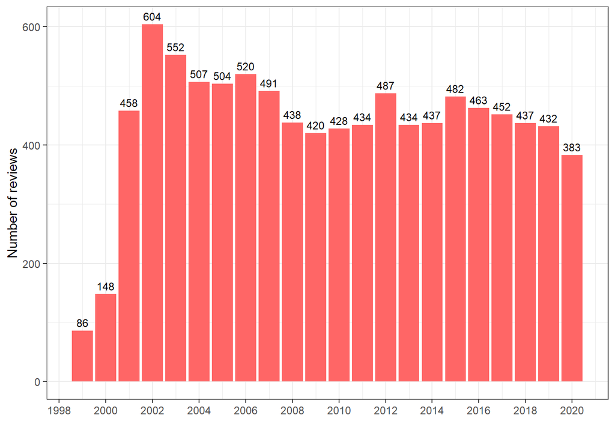

## 1. Does Pitchfork prefer reviewing certain types of music?

When looking at how the proportion of genres reviewed changed over time, Pitchfork’s coverage of Rock declined over the 21 years while for Rap and Pop/R&B it increased.

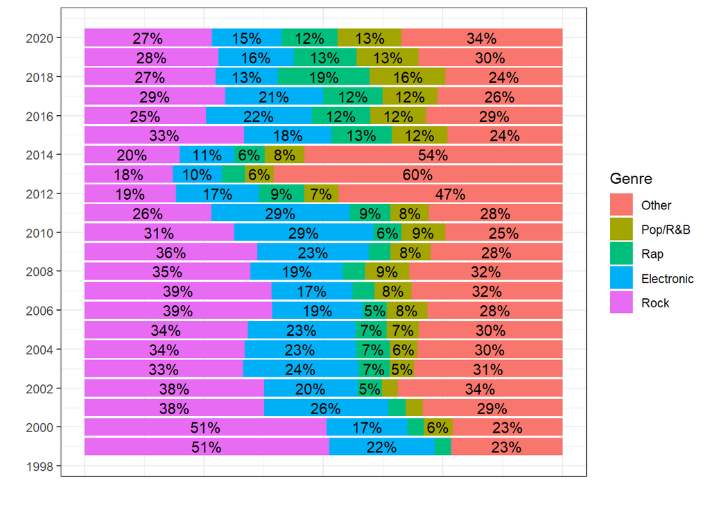

The plot below shows how the proportion of reviews by each of the “Other” genres changed between 1999 and 2020.

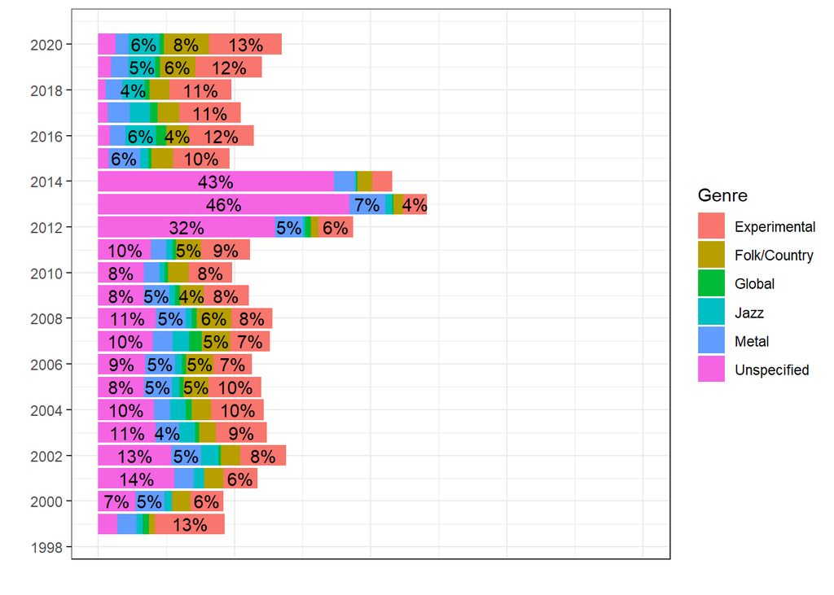

## 2. Which genre of music was the best (and worst) received?

This is likely because when it comes to less popular genres such as Jazz, Global and Experimental, there is a higher likelihood that reviews will ignore lesser known artists, and the more well-known artist are likelier to consistently produce the better music.

## 3. Did music get better over time?

To answer this question, below is a line of best fit that best expresses the relationship between album review scores and release date. The line of best fit was estimated using a Generalised Additive Model (GAM). The plot suggests that overall, music reviews have actually gotten worse between 1999 and 2020. Scores declined from 1999 until 2008, where scores remained steady until around 2014 where they started to improve again. Hopefully music remains getting better!

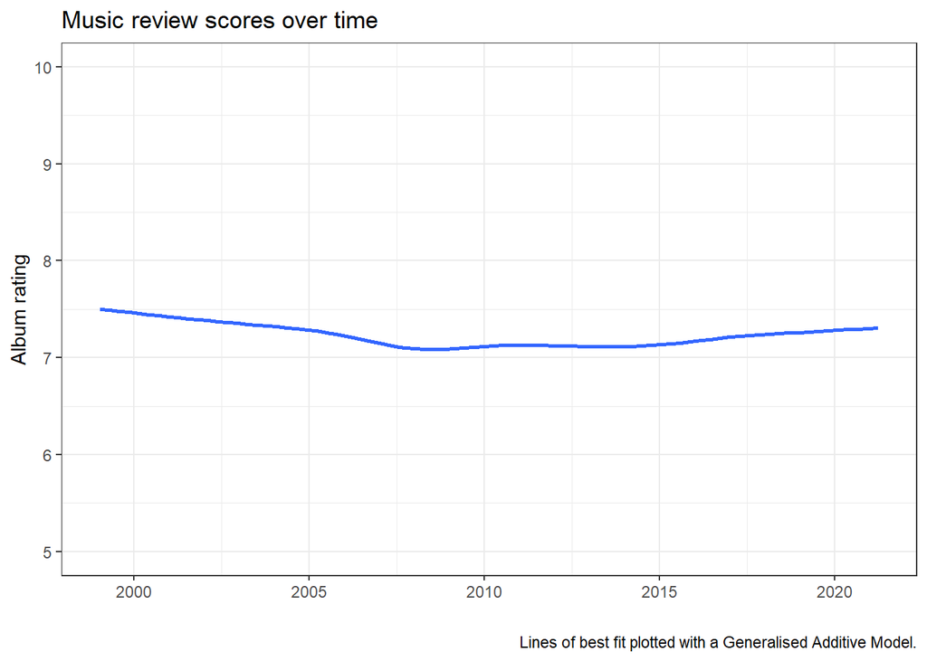

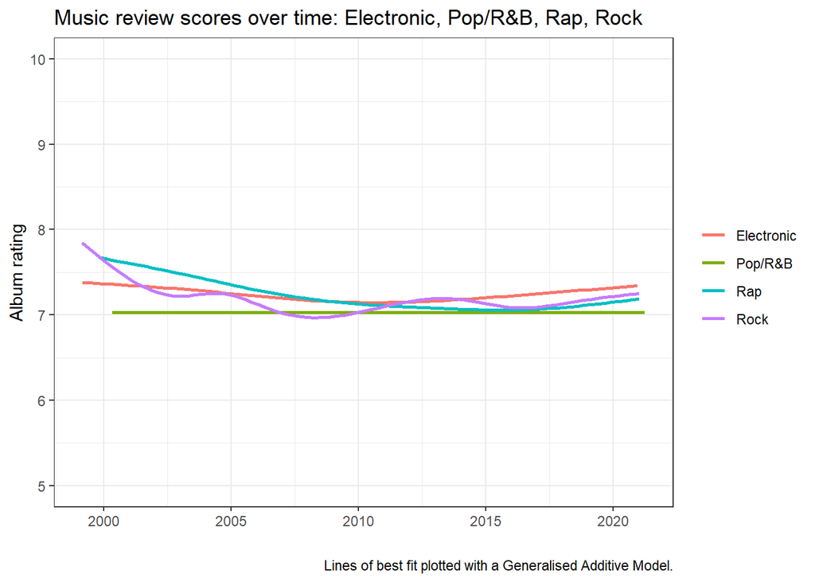

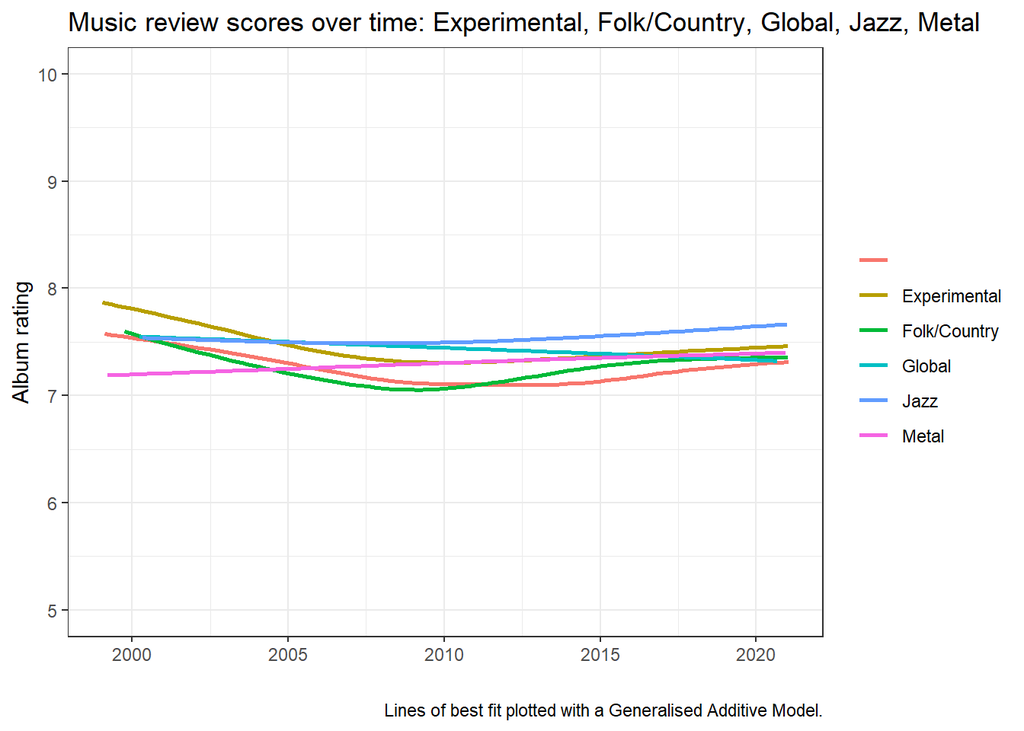

### 4. Which artists consistently produced the best music?

To answer this question I ranked each artist by their average album score and only included artists that had released at least three albums. The table below lists the 20 artists with the highest average album scores. The Velvet Underground tops the list (despite not producing any ‘new’ music in decades), while the relatively unknown Girls and Max Tundra come in at seccond and third respectively. Notably, several of the artists first produced the music receiving high ratings long ago. These include The Velvet Underground, John Coltrane, The Beach Boys, Miles Davis and Galaxie 500.

| Rank | Artist | Top three albums | Genre | # reviews | Average rating |
| --- | --- | --- | --- | --- | --- |
| 1 | The Velvet Underground | Bootleg Series, Vol. 1: The Quine Tapes (2001) \| Gold (2005) \| The Complete Matrix Tapes (2015) | Rock | 3 | 9.067 |
| 2 | Girls | Father, Son, Holy Ghost (2011) \| Album (2009) \| Broken Dreams Club EP (2010) | Rock | 3 | 9.033 |
| 3 | Max Tundra | Mastered by Guy at the Exchange (2002) \| Some Best Friend You Turned Out to Be (2000) \| Parallax Error Beheads You (2008) | Electronic \| Folk/Country | 3 | 9.000 |
| 4 | John Coltrane | The Olatunji Concert: The Last Live Recording (2001) \| A Love Supreme: The Complete Masters (2015) \| Both Directions at Once: The Lost Album (2018) | Jazz | 6 | 8.967 |
| 5 | Kendrick Lamar | good kid, m.A.A.d city (2012) \| To Pimp a Butterfly (2015) \| DAMN. (2017) | Rap | 5 | 8.920 |
| 6 | GAS | BOX (2016) \| Nah Und Fern (2008) \| Pop (2000) | Electronic | 5 | 8.860 |
| 7 | Scott Walker | 5 Easy Pieces (2003) \| The Drift (2006) \| Bish Bosch (2012) | Rock | 3 | 8.833 |
| 8 | Deafheaven | New Bermuda (2015) \| Sunbather (2013) \| Ordinary Corrupt Human Love (2018) | Metal | 3 | 8.800 |
| 9 | The Beach Boys | The Smile Sessions (2011) \| The Warmth of the Sun (2007) \| Love You (2000) | Rock | 3 | 8.800 |
| 10 | Fuck Buttons | Tarot Sport (2009) \| Slow Focus (2013) \| Street Horrrsing (2008) | Electronic | 3 | 8.767 |
| 11 | Pavement | Quarantine the Past (2010) \| Wowee Zowee: Sordid Sentinels Edition (2006) \| The Secret History, Vol. 1 (2015) | Rock | 3 | 8.767 |
| 12 | Joanna Newsom | Ys (2006) \| Have One on Me (2010) \| Joanna Newsom & the Ys Street Band EP (2007) | Folk/Country | 5 | 8.760 |
| 13 | Miles Davis | The Complete Birth of the Cool (2019) \| The Complete In a Silent Way Sessions (2001) \| The Cellar Door Sessions 1970 (2005) | Jazz | 9 | 8.756 |
| 14 | FKA twigs | MAGDALENE (2019) \| LP1 (2014) \| M3LL155X (2015) | Electronic \| Pop/R&B | 4 | 8.700 |
| 15 | Tame Impala | Currents (2015) \| Lonerism (2012) \| Innerspeaker (2010) | Rock | 4 | 8.700 |
| 16 | The Avalanches | Since I Left You (2001) \| Wildflower (2016) \| We Will Always Love You (2020) | Electronic | 3 | 8.700 |
| 17 | Galaxie 500 | On Fire (2010) \| Today (2010) \| Peel Sessions (2005) | Experimental \| Rock | 5 | 8.680 |
| 18 | Sleater-Kinney | Start Together (2014) \| One Beat (2002) \| The Woods (2005) | Rock | 7 | 8.643 |
| 19 | Morton Feldman | String Quartet II (2001) \| Patterns in a Chromatic Field (2004) \| The Viola in My Life (2008) | Experimental | 3 | 8.633 |
| 20 | Caetano Veloso | Antologia 69-03 (2003) \| A Foreign Sound (2004) \| Noites do Norte (2000) | Global | 3 | 8.600 |